# Nanodegree - Data Wrangling

### Project 04

- Introduction
- Part I - Gathering Data
- Part II - Assessing Data
- Part III - Cleaning Data
- Analyzing Data

### Introduction

This Jupyter Notebook is the final project of Data Wrangling. The project main go is to wrangle data, with these 3 steps:

- Data wrangling, which consists of:

1- Gathering data

2- Assessing data

3- Cleaning data

- Storing, analyzing, and visualizing your wrangled data
- Reporting on 1) your data wrangling efforts and 2) your data analyses and - - visualizations

*Data will be purchased with Twitter API from WeRateDogs archive. After gathering data, it'll be necessary to assessed, and then cleaned*

- To check the `Project Rubric`, [click here](https://review.udacity.com/#!/rubrics/1136/view).
- In case of doubts, review some concepts here

# What is WeRateDogs?

[figure not shown]

WeRateDogs is a Twitter profile that rate all kinds of cute dogs. The rates are always a little bit to high, but who cares? We just want to see fluffy doggos!

Besides the rates, they also have a classification of dogs based on their age and appearence:

- - Doggo
- - Floffer
- - Pupper
- - Puppo
- - Blep

In this document the WeRateDogs profile will be studied as a task of Udacity's Data Wrangling course.

##### We'll analyze things like:

1. Dog's name
2. Dog's classification
3. Number of likes and retweets
4. Length of tweets
5. And much more!

By the end of this notebook, all steps of data wrangling must have be completed:

- Gather data
- Assess data
- Clean data

### Part I - Gathering Data

```python
#Importing the required libraries
import pandas as pd
import numpy as np
import requests
from tweepy import OAuthHandler
import tweepy
import json
import os
from timeit import default_timer as timer
from datetime import datetime as dt
import re
```

```python
#Loading Twitter API Credentials

consumer_key = 'HIDDEN'
consumer_secret = 'HIDDEN'
access_token = 'HIDDEN'
access_secret = 'HIDDEN'

auth = OAuthHandler(consumer_key, consumer_secret)
auth.set_access_token(access_token, access_secret)

api = tweepy.API(auth, wait_on_rate_limit=True)
```

```python
# Creating a folder to save future data
folder_name = 'tweet_weratedogs'
if not os.path.exists(folder_name):
    os.makedirs(folder_name)
```

#### Access tweepy [documentation here!](https://buildmedia.readthedocs.org/media/pdf/tweepy/latest/tweepy.pdf)

```python
df_1 = pd.read_csv('twitter-archive-enhanced.csv')

tweet_ids = df_1.tweet_id.values
len(tweet_ids)

# Query Twitter's API for JSON data for each tweet ID in the Twitter archive
count = 0
fails_dict = {}
start = timer()
# Save each tweet's returned JSON as a new line in a .txt file
with open('tweet_json.txt', 'w') as outfile:
    # This loop will likely take 20-30 minutes to run because of Twitter's rate limit
    for tweet_id in tweet_ids:
        count += 1
        print(str(count) + ": " + str(tweet_id))
        try:
            tweet = api.get_status(tweet_id, tweet_mode='extended')
            print("Success")
            json.dump(tweet._json, outfile)
            outfile.write('\n')
        except tweepy.TweepError as e:
            print("Fail")
            fails_dict[tweet_id] = e
            pass
end = timer()
print(end - start)
print(fails_dict)
```

```
1: 892420643555336193
Success
2: 892177421306343426
Success
3: 891815181378084864
Success
4: 891689557279858688
Success
5: 891327558926688256
Success
6: 891087950875897856
Success
7: 890971913173991426
Success
8: 890729181411237888
Success
9: 890609185150312448
Success
10: 890240255349198849
Success
11: 890006608113172480
Success
12: 889880896479866881
Success
13: 889665388333682689
Success
14: 889638837579907072
Success
15: 889531135344209921
Success
16: 889278841981685760
Success
17: 888917238123831296
Success
18: 888804989199671297
Success
19: 888554962724278272
Success
20: 888202515573088257
Fail
```

[output cut: 4659 more lines]

```
Success
2351: 666050758794694657
Success
2352: 666049248165822465
Success
2353: 666044226329800704
Success
2354: 666033412701032449
Success
2355: 666029285002620928
Success
2356: 666020888022790149
Success
1990.9146088
{888202515573088257: TweepError([{'code': 144, 'message': 'No status found with that ID.'}]), 873697596434513921: TweepError([{'code': 144, 'message': 'No status found with that ID.'}]), 872668790621863937: TweepError([{'code': 144, 'message': 'No status found with that ID.'}]), 872261713294495745: …
```

Source of the [code below](https://stackoverflow.com/questions/21058935/python-json-loads-shows-valueerror-extra-data/51830719)

```python
#Reading the tweet_json.txt file as json and putting in a dictornary.
tweets_ids = []
for line in open('tweet-json.txt', 'r'):
    tweets_ids.append(json.loads(line))
```

```python
#List of dictionaries to build file by file and later convert to a DataFrame
#This was the code I made to gather data from tweet_json.txt to a pandas dataframe. But, I don't know why it didn't run.
#Looking for a answer, I'll let this here. If I cannot make to a solution, send this to the mentor, he might help you.
#The code structure was all correct. The only problem was that The variable `t` is not the index but it is the row itself.
#So instead of `tweet_ids[t]['id']` you'd have to write it as `t['id']`.
df_list = []
for t in tweets_ids:
    tweet_id = t['id']
    full_text = t['full_text']
    rt_count = t['retweet_count']
    fav_count = t['favorite_count']
    display_text_range = t['display_text_range']
    date = t['created_at']
    retweeted = t['retweeted']

    df_list.append({'tweet_id': tweet_id,
                    "full_text":full_text,
                   'rt_count': rt_count,
                    'fav_count': fav_count,
                   'display_text_range':display_text_range,
                   'date':date,
                   'rt':retweeted})
df = pd.DataFrame(df_list, columns = [ 'date','tweet_id', 'full_text','fav_count','rt_count','display_text_range', 'rt'])
```

```python
df.sample(3)
```

|  | date | tweet_id | full_text | fav_count | rt_count | display_text_range | rt |
| --- | --- | --- | --- | --- | --- | --- | --- |
| 125 | Sat May 27 19:39:34 +0000 2017 | 868552278524837888 | Say hello to Cooper. His expression is the sam... | 10539 | 2240 | [0, 139] | False |
| 1905 | Wed Dec 09 04:36:06 +0000 2015 | 674447403907457024 | This pupper just wants a belly rub. This puppe... | 1137 | 393 | [0, 138] | False |
| 168 | Tue May 02 00:04:57 +0000 2017 | 859196978902773760 | We only rate dogs. This is quite clearly a smo... | 75193 | 25661 | [0, 124] | False |

### Part II - Assessing Data

##### Describe this part

`What I have to do`

- Make a column for dogs name
- Make a column for the rates
- Remove retweets from tweets
- To assess and clean at least 8 quality issues and at least 2 tidiness issues in this dataset.
- Insert datetime columns from the original dataframe
- Get images from each text
- You do not need to gather the tweets beyond August 1st, 2017.
- Separate datetime in weekday, date and hour

```python
#creating a copy

tweets = df.copy()
df_i = pd.read_csv('image-predictions.tsv',sep = "	")
image = df_i.copy()
```

```python
tweets.head()
```

|  | date | tweet_id | full_text | fav_count | rt_count | display_text_range | rt |
| --- | --- | --- | --- | --- | --- | --- | --- |
| 0 | Tue Aug 01 16:23:56 +0000 2017 | 892420643555336193 | This is Phineas. He's a mystical boy. Only eve... | 39467 | 8853 | [0, 85] | False |
| 1 | Tue Aug 01 00:17:27 +0000 2017 | 892177421306343426 | This is Tilly. She's just checking pup on you.... | 33819 | 6514 | [0, 138] | False |
| 2 | Mon Jul 31 00:18:03 +0000 2017 | 891815181378084864 | This is Archie. He is a rare Norwegian Pouncin... | 25461 | 4328 | [0, 121] | False |
| 3 | Sun Jul 30 15:58:51 +0000 2017 | 891689557279858688 | This is Darla. She commenced a snooze mid meal... | 42908 | 8964 | [0, 79] | False |
| 4 | Sat Jul 29 16:00:24 +0000 2017 | 891327558926688256 | This is Franklin. He would like you to stop ca... | 41048 | 9774 | [0, 138] | False |

```python
tweets.tail()
```

|  | date | tweet_id | full_text | fav_count | rt_count | display_text_range | rt |
| --- | --- | --- | --- | --- | --- | --- | --- |
| 2349 | Mon Nov 16 00:24:50 +0000 2015 | 666049248165822465 | Here we have a 1949 1st generation vulpix. Enj... | 111 | 41 | [0, 120] | False |
| 2350 | Mon Nov 16 00:04:52 +0000 2015 | 666044226329800704 | This is a purebred Piers Morgan. Loves to Netf... | 311 | 147 | [0, 137] | False |
| 2351 | Sun Nov 15 23:21:54 +0000 2015 | 666033412701032449 | Here is a very happy pup. Big fan of well-main... | 128 | 47 | [0, 130] | False |
| 2352 | Sun Nov 15 23:05:30 +0000 2015 | 666029285002620928 | This is a western brown Mitsubishi terrier. Up... | 132 | 48 | [0, 139] | False |
| 2353 | Sun Nov 15 22:32:08 +0000 2015 | 666020888022790149 | Here we have a Japanese Irish Setter. Lost eye... | 2535 | 532 | [0, 131] | False |

```python
tweets.shape
```

```
(2354, 7)
```

```python
tweets.date.min(), tweets.date.max()
```

```
('Fri Apr 01 00:26:15 +0000 2016', 'Wed Sep 28 21:56:36 +0000 2016')
```

```python
tweets.info() #Slip date format and transform to datetime.
```

```
<class 'pandas.core.frame.DataFrame'>
RangeIndex: 2354 entries, 0 to 2353
Data columns (total 7 columns):
 #   Column              Non-Null Count  Dtype
---  ------              --------------  -----
 0   date                2354 non-null   object
 1   tweet_id            2354 non-null   int64
 2   full_text           2354 non-null   object
 3   fav_count           2354 non-null   int64
 4   rt_count            2354 non-null   int64
 5   display_text_range  2354 non-null   object
 6   rt                  2354 non-null   bool
dtypes: bool(1), int64(3), object(3)
memory usage: 112.8+ KB
```

```python
tweets.describe()
```

|  | tweet_id | fav_count | rt_count |
| --- | --- | --- | --- |
| count | 2.354000e+03 | 2354.000000 | 2354.000000 |
| mean | 7.426978e+17 | 8080.968564 | 3164.797366 |
| std | 6.852812e+16 | 11814.771334 | 5284.770364 |
| min | 6.660209e+17 | 0.000000 | 0.000000 |
| 25% | 6.783975e+17 | 1415.000000 | 624.500000 |
| 50% | 7.194596e+17 | 3603.500000 | 1473.500000 |
| 75% | 7.993058e+17 | 10122.250000 | 3652.000000 |
| max | 8.924206e+17 | 132810.000000 | 79515.000000 |

```python
tweets.full_text[0]
```

```
"This is Phineas. He's a mystical boy. Only ever appears in the hole of a donut. 13/10 https://t.co/MgUWQ76dJU"
```

```python
tweets[tweets['full_text'].isnull()]
```

|  | date | tweet_id | full_text | fav_count | rt_count | display_text_range | rt |
| --- | --- | --- | --- | --- | --- | --- | --- |

```python
tweets[tweets['tweet_id'].duplicated()]
```

|  | date | tweet_id | full_text | fav_count | rt_count | display_text_range | rt |
| --- | --- | --- | --- | --- | --- | --- | --- |

```python
image.shape
```

```
(2075, 12)
```

##### Quality

- Date is string, not datetime ✅
- Remove RTs, they're not the targeted data. ✅
- Date has inconsistent numbers (000) ✅
- Change text range from list (string) to int ✅
- `tweets_id`should be obj not int ✅
- Outliners numbers in `numerator` (45) ✅
- Change all `denominator` to 10. ✅
- `numerator`change to float. ✅
- Dogs names are incorrect, for example `a carrot`, `a might`.✅

##### Tidiness

- One column with 3 variables (full text, rate and url)
- Put together the dataframes
- Creat a column with dog stages

### Tidiness

##### Define

- Transform the json date format to datetime. ##### Code

```python
#Creating a new column named TIME and converting date column to_datetime
tweets.date = pd.to_datetime(tweets.date, utc = False)
```

```python
tweets.date.head()
```

```
0   2017-08-01 16:23:56+00:00
1   2017-08-01 00:17:27+00:00
2   2017-07-31 00:18:03+00:00
3   2017-07-30 15:58:51+00:00
4   2017-07-29 16:00:24+00:00
Name: date, dtype: datetime64[ns, UTC]
```

```python
#Checking all variables
tweets.dtypes
```

```
date                  datetime64[ns, UTC]
tweet_id                            int64
full_text                          object
fav_count                           int64
rt_count                            int64
display_text_range                 object
rt                                   bool
dtype: object
```

##### Define

- Get the dogs names in the full text column with str.extract.
- Get the dominator and denominator, then, create columns for both

##### Code

```python
tweets.full_text[0]
```

```
"This is Phineas. He's a mystical boy. Only ever appears in the hole of a donut. 13/10 https://t.co/MgUWQ76dJU"
```

#### Patterns to introduce dogs

- This is
- Meet
- Say hello to XX and YY
- named ...
- His name is
- Her name is

Check in here [some tips](https://knowledge.udacity.com/questions/110233) to keep on developing this part. And [this one as well](https://knowledge.udacity.com/questions/115348)

```python
tweets.head()
```

|  | date | tweet_id | full_text | fav_count | rt_count | display_text_range | rt |
| --- | --- | --- | --- | --- | --- | --- | --- |
| 0 | 2017-08-01 16:23:56+00:00 | 892420643555336193 | This is Phineas. He's a mystical boy. Only eve... | 39467 | 8853 | [0, 85] | False |
| 1 | 2017-08-01 00:17:27+00:00 | 892177421306343426 | This is Tilly. She's just checking pup on you.... | 33819 | 6514 | [0, 138] | False |
| 2 | 2017-07-31 00:18:03+00:00 | 891815181378084864 | This is Archie. He is a rare Norwegian Pouncin... | 25461 | 4328 | [0, 121] | False |
| 3 | 2017-07-30 15:58:51+00:00 | 891689557279858688 | This is Darla. She commenced a snooze mid meal... | 42908 | 8964 | [0, 79] | False |
| 4 | 2017-07-29 16:00:24+00:00 | 891327558926688256 | This is Franklin. He would like you to stop ca... | 41048 | 9774 | [0, 138] | False |

```python
#Making a loop to extract dogs name with the regex.
dogs_name = []
for text in tweets.full_text:
    search = re.search(r"^[Nn]amed (.+?). ", text) or re.search(r"^[Tt]his is\s(.+?). ", text) or re.search(r"^[Mm]eet (.+?). ", text) or re.search(r"^[Ss]ay hello to (.+?). ", text) or re.search(r"^[Nn]ame is (.+?). ", text)
    if search is not None:
        dogs_name.append(search.group(1))
#In this part, it's necessary to fullfill the empty spaces, otherwise there's gonna be an error in the output.
    else: dogs_name.append('NaN')
```

```python
#Creating a new column with dog names.
tweets['dogs_name'] = dogs_name
```

```python
#I saw some inconsistencies, for example, the dog name wasn't extracted, but it's caractheristic. This is a quality issue.
#Must be fixed.
tweets.query('dogs_name.str.contains("a ")', engine='python')
```

|  | date | tweet_id | full_text | fav_count | rt_count | display_text_range | rt | dogs_name |
| --- | --- | --- | --- | --- | --- | --- | --- | --- |
| 1000 | 2016-06-28 20:14:22+00:00 | 747885874273214464 | This is a mighty rare blue-tailed hammer sherk... | 3243 | 1116 | [0, 116] | False | a might |
| 1015 | 2016-06-26 01:08:52+00:00 | 746872823977771008 | This is a carrot. We only rate dogs. Please on... | 6593 | 2429 | [0, 110] | False | a carrot |
| 1047 | 2016-06-15 23:24:09+00:00 | 743222593470234624 | This is a very rare Great Alaskan Bush Pupper.... | 6792 | 2164 | [0, 114] | False | a ver |
| 1205 | 2016-04-01 02:51:22+00:00 | 715733265223708672 | This is a taco. We only rate dogs. Please only... | 5093 | 1920 | [0, 137] | False | a taco |
| 1359 | 2016-02-26 04:48:02+00:00 | 703079050210877440 | This is a Butternut Cumberfloof. It's not wind... | 8064 | 3494 | [0, 139] | False | a Butternu |
| 1366 | 2016-02-24 17:04:07+00:00 | 702539513671897089 | This is a Wild Tuscan Poofwiggle. Careful not ... | 3134 | 1091 | [0, 136] | False | a Wil |
| 1497 | 2016-01-27 03:26:56+00:00 | 692187005137076224 | This is a rare Arctic Wubberfloof. Unamused by... | 2768 | 929 | [0, 139] | False | a rar |
| 1783 | 2015-12-18 00:18:36+00:00 | 677644091929329666 | This is a dog swinging. I really enjoyed it so... | 2040 | 886 | [0, 103] | False | a do |
| 1851 | 2015-12-12 15:59:51+00:00 | 675706639471788032 | This is a Sizzlin Menorah spaniel from Brookly... | 693 | 106 | [0, 140] | False | a Sizzli |
| 1876 | 2015-12-10 20:19:52+00:00 | 675047298674663426 | This is a fluffy albino Bacardi Columbia mix. ... | 1141 | 366 | [0, 117] | False | a fluff |
| 1921 | 2015-12-08 04:27:30+00:00 | 674082852460433408 | This is a Sagitariot Baklava mix. Loves her ne... | 804 | 186 | [0, 94] | False | a Sagitario |
| 1939 | 2015-12-07 04:09:13+00:00 | 673715861853720576 | This is a heavily opinionated dog. Loves walls... | 3815 | 2303 | [0, 134] | False | a heavil |
| 1953 | 2015-12-06 22:54:44+00:00 | 673636718965334016 | This is a Lofted Aphrodisiac Terrier named Kip... | 1194 | 404 | [0, 139] | False | a Lofte |
| 1992 | 2015-12-04 02:31:10+00:00 | 672604026190569472 | This is a baby Rand Paul. Curls for days. 11/1... | 1188 | 445 | [0, 100] | False | a bab |
| 2032 | 2015-12-01 17:30:22+00:00 | 671743150407421952 | This is a Tuscaloosa Alcatraz named Jacob (Yac... | 779 | 248 | [0, 136] | False | a Tuscaloos |
| 2064 | 2015-11-30 02:01:49+00:00 | 671147085991960577 | This is a Helvetica Listerine named Rufus. Thi... | 713 | 254 | [0, 140] | False | a Helvetic |
| 2114 | 2015-11-28 02:20:27+00:00 | 670427002554466305 | This is a Deciduous Trimester mix named Spork.... | 551 | 179 | [0, 139] | False | a Deciduou |
| 2123 | 2015-11-27 22:01:40+00:00 | 670361874861563904 | This is a Rich Mahogany Seltzer named Cherokee... | 344 | 71 | [0, 137] | False | a Ric |
| 2126 | 2015-11-27 18:09:09+00:00 | 670303360680108032 | This is a Speckled Cauliflower Yosemite named ... | 452 | 151 | [0, 138] | False | a Speckle |
| 2144 | 2015-11-26 16:59:01+00:00 | 669923323644657664 | This is a spotted Lipitor Rumpelstiltskin name... | 250 | 64 | [0, 138] | False | a spotte |
| 2151 | 2015-11-25 23:39:47+00:00 | 669661792646373376 | This is a brave dog. Excellent free climber. T... | 860 | 482 | [0, 139] | False | a brav |
| 2159 | 2015-11-25 17:13:02+00:00 | 669564461267722241 | This is a Coriander Baton Rouge named Alfredo.... | 413 | 133 | [0, 138] | False | a Coriande |
| 2189 | 2015-11-24 00:54:05+00:00 | 668955713004314625 | This is a Slovakian Helter Skelter Feta named ... | 300 | 77 | [0, 140] | False | a Slovakia |
| 2196 | 2015-11-23 15:35:39+00:00 | 668815180734689280 | This is a wild Toblerone from Papua New Guinea... | 610 | 291 | [0, 137] | False | a wil |
| 2216 | 2015-11-22 19:13:05+00:00 | 668507509523615744 | This is a Birmingham Quagmire named Chuk. Love... | 345 | 116 | [0, 138] | False | a Birmingha |
| 2233 | 2015-11-21 20:59:20+00:00 | 668171859951755264 | This is a Trans Siberian Kellogg named Alfonso... | 525 | 208 | [0, 129] | False | a Tran |
| 2247 | 2015-11-21 00:25:26+00:00 | 667861340749471744 | This is a Shotokon Macadamia mix named Cheryl.... | 253 | 86 | [0, 140] | False | a Shotoko |
| 2253 | 2015-11-20 18:35:10+00:00 | 667773195014021121 | This is a rare Hungarian Pinot named Jessiga. ... | 243 | 61 | [0, 136] | False | a rar |
| 2262 | 2015-11-20 03:04:08+00:00 | 667538891197542400 | This is a southwest Coriander named Klint. Hat... | 220 | 72 | [0, 117] | False | a southwes |
| 2271 | 2015-11-19 22:32:36+00:00 | 667470559035432960 | This is a northern Wahoo named Kohl. He runs t... | 273 | 102 | [0, 138] | False | a norther |
| 2285 | 2015-11-19 03:10:02+00:00 | 667177989038297088 | This is a Dasani Kingfisher from Maine. His na... | 200 | 58 | [0, 134] | False | a Dasan |
| 2302 | 2015-11-18 14:18:59+00:00 | 666983947667116034 | This is a curly Ticonderoga named Pepe. No fee... | 2679 | 1040 | [0, 120] | False | a curl |
| 2309 | 2015-11-18 00:55:42+00:00 | 666781792255496192 | This is a purebred Bacardi named Octaviath. Ca... | 404 | 211 | [0, 107] | False | a purebre |
| 2312 | 2015-11-17 19:35:19+00:00 | 666701168228331520 | This is a golden Buckminsterfullerene named Jo... | 449 | 234 | [0, 139] | False | a golde |
| 2325 | 2015-11-17 00:06:54+00:00 | 666407126856765440 | This is a southern Vesuvius bumblegruff. Can d... | 113 | 44 | [0, 139] | False | a souther |
| 2332 | 2015-11-16 16:37:02+00:00 | 666293911632134144 | This is a funny dog. Weird toes. Won't come do... | 522 | 368 | [0, 138] | False | a funn |
| 2348 | 2015-11-16 00:30:50+00:00 | 666050758794694657 | This is a truly beautiful English Wilson Staff... | 136 | 60 | [0, 140] | False | a trul |
| 2350 | 2015-11-16 00:04:52+00:00 | 666044226329800704 | This is a purebred Piers Morgan. Loves to Netf... | 311 | 147 | [0, 137] | False | a purebre |
| 2352 | 2015-11-15 23:05:30+00:00 | 666029285002620928 | This is a western brown Mitsubishi terrier. Up... | 132 | 48 | [0, 139] | False | a wester |

#### Define

- Extract the URL with str.extrac and put in anothe column

#### Code

```python
#Using regex to extract all the URL's code
link = tweets.full_text.str.extract(r'(https://t.co/+([a-zA-Z0-9()@:%_\+.~#?&//=]*))', expand=True)
#Creating a column with the url output
tweets['tweets_url'] = link[0]
tweets.head()
```

|  | date | tweet_id | full_text | fav_count | rt_count | display_text_range | rt | dogs_name | tweets_url |
| --- | --- | --- | --- | --- | --- | --- | --- | --- | --- |
| 0 | 2017-08-01 16:23:56+00:00 | 892420643555336193 | This is Phineas. He's a mystical boy. Only eve... | 39467 | 8853 | [0, 85] | False | Phineas | https://t.co/MgUWQ76dJU |
| 1 | 2017-08-01 00:17:27+00:00 | 892177421306343426 | This is Tilly. She's just checking pup on you.... | 33819 | 6514 | [0, 138] | False | Tilly | https://t.co/0Xxu71qeIV |
| 2 | 2017-07-31 00:18:03+00:00 | 891815181378084864 | This is Archie. He is a rare Norwegian Pouncin... | 25461 | 4328 | [0, 121] | False | Archie | https://t.co/wUnZnhtVJB |
| 3 | 2017-07-30 15:58:51+00:00 | 891689557279858688 | This is Darla. She commenced a snooze mid meal... | 42908 | 8964 | [0, 79] | False | Darla | https://t.co/tD36da7qLQ |
| 4 | 2017-07-29 16:00:24+00:00 | 891327558926688256 | This is Franklin. He would like you to stop ca... | 41048 | 9774 | [0, 138] | False | Franklin | https://t.co/AtUZn91f7f |

#### Define

- Extract the rates str.extrac and put in another column

#### Code

```python
tweets['numerator'] = tweets.full_text.str.extract('((?:\d+\.)?\d+)', expand=True)
tweets.numerator
```

```
0         13
1         13
2         12
3         13
4         12
        ...
2349    1949
2350       6
2351       9
2352       2
2353       8
Name: numerator, Length: 2354, dtype: object
```

```python
tweets.numerator.value_counts()
```

```
12       544
10       447
11       442
13       341
9        149
        ...
84         1
47         1
92.49      1
46         1
97         1
Name: numerator, Length: 63, dtype: int64
```

```python
tweets['denominator'] = tweets.full_text.str.extract('\/(\d+)', expand = True)
tweets.denominator
```

```
0       10
1       10
2       10
3       10
4       10
        ..
2349    10
2350    10
2351    10
2352    10
2353    10
Name: denominator, Length: 2354, dtype: object
```

```python
tweets.denominator.value_counts()
```

```
10     2331
50        3
11        3
80        2
20        2
15        1
2         1
00        1
70        1
40        1
16        1
130       1
90        1
7         1
120       1
170       1
150       1
110       1
Name: denominator, dtype: int64
```

```python
tweets = pd.merge(tweets, image, on=['tweet_id'],how='left')
```

### Quality

- Date is string, not datetime ✅
- Remove RTs, they're not the targeted data. ✅
- Date has inconsistent numbers (000) ✅
- Change text range from list (string) to int ✅
- `tweets_id`should be obj not int ✅
- Outliners numbers in `numerator` (45) ✅
- Change all `denominator` to 10. ✅
- `numerator`change to float. ✅
- Dogs names are incorrect, for example `a carrot`, `a might`.✅

#### Define

- Transform all denominators into 10s by renaming the rows. With this, all outliners will be removed.

#### Code

```python
#Changing all the denominators outliners to 10.
tweets["denominator"] = 10
tweets.denominator.value_counts()
```

```
10    2354
Name: denominator, dtype: int64
```

#### Define

- Transform all numerator datatype to float with to_numeric.

#### Code

```python
#Changing the numerator datatype from obj to float.
tweets.numerator = pd.to_numeric(tweets.numerator)
tweets.numerator.dtypes
```

```
dtype('float64')
```

#### Code

```python
#Transforming all numerator rate that is above 18 to tweets.mode

tweets.numerator[tweets.numerator > 20] = tweets.numerator.mode()
```

#### Define

- Remove all RTs from the dataframe. For this we'll use inverse selection with `~`

#### Code

```python
# Using the ~ to select the inverse, then creating a new dataframe.
tweets = tweets[~tweets["full_text"].str.contains("RT @")]
```

#### Define

- Get the highest number in `display_text_range` with str.extract, put in a new column, then convert to int. #### Code

```python
#creating a list to put all the variables
df_range = []

for i in tweets.display_text_range:
    rangex = i[1]
    df_range.append(rangex)
#in here, a for loop was created to get all high-number in the display_text_range
#now creating a column
tweets['tweet_limit'] = df_range
#changing datatype
tweets.tweet_limit.astype(int)
#tweets = tweets.drop('display_text_range', axis = 1)
tweets.tweet_limit.head()
tweets.head()
```

|  | date | tweet_id | full_text | fav_count | rt_count | display_text_range | rt | dogs_name | tweets_url | numerator | ... | p1 | p1_conf | p1_dog | p2 | p2_conf | p2_dog | p3 | p3_conf | p3_dog | tweet_limit |
| --- | --- | --- | --- | --- | --- | --- | --- | --- | --- | --- | --- | --- | --- | --- | --- | --- | --- | --- | --- | --- | --- |
| 0 | 2017-08-01 16:23:56+00:00 | 892420643555336193 | This is Phineas. He's a mystical boy. Only eve... | 39467 | 8853 | [0, 85] | False | Phineas | https://t.co/MgUWQ76dJU | 13.0 | ... | orange | 0.097049 | False | bagel | 0.085851 | False | banana | 0.076110 | False | 85 |
| 1 | 2017-08-01 00:17:27+00:00 | 892177421306343426 | This is Tilly. She's just checking pup on you.... | 33819 | 6514 | [0, 138] | False | Tilly | https://t.co/0Xxu71qeIV | 13.0 | ... | Chihuahua | 0.323581 | True | Pekinese | 0.090647 | True | papillon | 0.068957 | True | 138 |
| 2 | 2017-07-31 00:18:03+00:00 | 891815181378084864 | This is Archie. He is a rare Norwegian Pouncin... | 25461 | 4328 | [0, 121] | False | Archie | https://t.co/wUnZnhtVJB | 12.0 | ... | Chihuahua | 0.716012 | True | malamute | 0.078253 | True | kelpie | 0.031379 | True | 121 |
| 3 | 2017-07-30 15:58:51+00:00 | 891689557279858688 | This is Darla. She commenced a snooze mid meal... | 42908 | 8964 | [0, 79] | False | Darla | https://t.co/tD36da7qLQ | 13.0 | ... | paper_towel | 0.170278 | False | Labrador_retriever | 0.168086 | True | spatula | 0.040836 | False | 79 |
| 4 | 2017-07-29 16:00:24+00:00 | 891327558926688256 | This is Franklin. He would like you to stop ca... | 41048 | 9774 | [0, 138] | False | Franklin | https://t.co/AtUZn91f7f | 12.0 | ... | basset | 0.555712 | True | English_springer | 0.225770 | True | German_short-haired_pointer | 0.175219 | True | 138 |

5 rows × 23 columns

#### Define

- Remove the +000 from the date column with `dt.strftime` . #### Code

```python
#Changing the datatype of Date column.
tweets.date = tweets.date.dt.strftime('%Y-%m-%d %H:%M:%S')
tweets.date.head()
```

```
0    2017-08-01 16:23:56
1    2017-08-01 00:17:27
2    2017-07-31 00:18:03
3    2017-07-30 15:58:51
4    2017-07-29 16:00:24
Name: date, dtype: object
```

#### Define

- Create dogs classification with str.extract.

#### Code

```python
#Uploading a new CSV with dogs stage and creating a new dataframe
df_dogs = pd.read_csv('twitter-archive-enhanced.csv')
#Separating the columns of interest with pd.filter. Then, printing the head.
dog_stage = df_dogs.filter(items=['tweet_id' ,'doggo', 'floofer', 'pupper', 'puppo'])
dog_stage.head()
```

|  | tweet_id | doggo | floofer | pupper | puppo |
| --- | --- | --- | --- | --- | --- |
| 0 | 892420643555336193 | None | None | None | None |
| 1 | 892177421306343426 | None | None | None | None |
| 2 | 891815181378084864 | None | None | None | None |
| 3 | 891689557279858688 | None | None | None | None |
| 4 | 891327558926688256 | None | None | None | None |

```python
dog_stage.puppo.value_counts()
```

```
None     2326
puppo      30
Name: puppo, dtype: int64
```

```python
# handle none
dog_stage.doggo.replace('None', '', inplace=True)
dog_stage.floofer.replace('None', '', inplace=True)
dog_stage.pupper.replace('None', '', inplace=True)
dog_stage.puppo.replace('None', '', inplace=True)
```

```python
#Creating a the column with all dog stages
dog_stage['dog_stages'] = dog_stage.doggo + dog_stage.puppo + dog_stage.floofer + dog_stage.pupper
dog_stage.dog_stages.value_counts()
```

```
                1976
pupper           245
doggo             83
puppo             29
doggopupper       12
floofer            9
doggopuppo         1
doggofloofer       1
Name: dog_stages, dtype: int64
```

```python
# handle multiple stages
dog_stage.loc[dog_stage.dog_stages == 'doggopupper', 'dog_stages'] = 'doggo, pupper'
dog_stage.loc[dog_stage.dog_stages == 'doggopuppo', 'dog_stages'] = 'doggo, puppo'
dog_stage.loc[dog_stage.dog_stages == 'doggofloofer', 'dog_stages'] = 'doggo, floofer'

# handle missing values
dog_stage.loc[dog_stage.dog_stages == '', 'dog_stages'] = np.nan
```

```python
dog_stage.dog_stages.value_counts()
```

```
pupper            245
doggo              83
puppo              29
doggo, pupper      12
floofer             9
doggo, puppo        1
doggo, floofer      1
Name: dog_stages, dtype: int64
```

```python
# Merging both dataframes
tweets = pd.merge(tweets, dog_stage, on=['tweet_id'],how='left')
```

```python
tweets.columns
```

```
Index(['date', 'tweet_id', 'full_text', 'fav_count', 'rt_count',
       'display_text_range', 'rt', 'dogs_name', 'tweets_url', 'numerator',
       'denominator', 'jpg_url', 'img_num', 'p1', 'p1_conf', 'p1_dog', 'p2',
       'p2_conf', 'p2_dog', 'p3', 'p3_conf', 'p3_dog', 'tweet_limit', 'doggo',
       'floofer', 'pupper', 'puppo', 'dog_stages'],
      dtype='object')
```

```python
tweets.dog_stages.value_counts()
```

```
pupper            224
doggo              75
puppo              24
doggo, pupper      10
floofer             9
doggo, puppo        1
doggo, floofer      1
Name: dog_stages, dtype: int64
```

```python
tweets = tweets.drop('doggo', axis = 1)
tweets = tweets.drop('pupper', axis = 1)
tweets = tweets.drop('puppo', axis = 1)
tweets = tweets.drop('floofer', axis = 1)
```

```python
tweets.columns
```

```
Index(['date', 'tweet_id', 'full_text', 'fav_count', 'rt_count',
       'display_text_range', 'rt', 'dogs_name', 'tweets_url', 'numerator',
       'denominator', 'jpg_url', 'img_num', 'p1', 'p1_conf', 'p1_dog', 'p2',
       'p2_conf', 'p2_dog', 'p3', 'p3_conf', 'p3_dog', 'tweet_limit',
       'dog_stages'],
      dtype='object')
```

#### Code

```python
#Select all rows that don't start with "a ". This is will return without these inconsistencies.
tweets = tweets[~tweets["dogs_name"].str.contains("a ")]
```

```python
tweets.dogs_name
```

```
0        Phineas
1          Tilly
2         Archie
3          Darla
4       Franklin
          ...
2167         NaN
2168           a
2170         NaN
2172         NaN
2174         NaN
Name: dogs_name, Length: 2136, dtype: object
```

```python
#Checking if it worked
tweets.query('dogs_name.str.contains("a ")', engine='python')
```

|  | date | tweet_id | full_text | fav_count | rt_count | display_text_range | rt | dogs_name | tweets_url | numerator | ... | p1_conf | p1_dog | p2 | p2_conf | p2_dog | p3 | p3_conf | p3_dog | tweet_limit | dog_stages |
| --- | --- | --- | --- | --- | --- | --- | --- | --- | --- | --- | --- | --- | --- | --- | --- | --- | --- | --- | --- | --- | --- |

0 rows × 24 columns

```python
#In here, another part of the inconsistency.
tweets.query('dogs_name.str.contains("th")', engine='python')
```

|  | date | tweet_id | full_text | fav_count | rt_count | display_text_range | rt | dogs_name | tweets_url | numerator | ... | p1_conf | p1_dog | p2 | p2_conf | p2_dog | p3 | p3_conf | p3_dog | tweet_limit | dog_stages |
| --- | --- | --- | --- | --- | --- | --- | --- | --- | --- | --- | --- | --- | --- | --- | --- | --- | --- | --- | --- | --- | --- |
| 756 | 2016-07-17 18:38:22 | 754747087846248448 | This is Keith. He's pursuing a more 2D lifesty... | 2854 | 591 | [0, 98] | False | Keith | https://t.co/G9ufksBMlU | 2.0 | ... | 0.471493 | False | cash_machine | 0.250837 | False | sliding_door | 0.117872 | False | 98 | NaN |
| 942 | 2016-05-13 16:15:54 | 731156023742988288 | Say hello to this unbelievably well behaved sq... | 4196 | 1434 | [0, 97] | False | thi | https://t.co/yGQI3He3xv | NaN | ... | 0.501767 | False | breakwater | 0.051351 | False | king_penguin | 0.049444 | False | 97 | NaN |
| 982 | 2016-04-23 22:38:43 | 724004602748780546 | This is Luther. He saw a ghost. Spooked af. 11... | 4561 | 1790 | [0, 70] | False | Luther | https://t.co/EdKG43VvEl | 11.0 | ... | 0.950526 | False | pug | 0.018877 | True | quilt | 0.007628 | False | 70 | pupper |
| 1131 | 2016-03-08 03:00:15 | 707038192327901184 | This is Kathmandu. He sees every move you make... | 2404 | 900 | [0, 117] | False | Kathmandu | https://t.co/z0cs7E4Xjj | 10.0 | ... | 0.642426 | True | llama | 0.057306 | False | French_bulldog | 0.054186 | True | 117 | NaN |
| 1156 | 2016-03-03 03:51:44 | 705239209544720384 | This is Jimothy. He lost his body during the t... | 3290 | 854 | [0, 116] | False | Jimothy | https://t.co/wnsblfu7XE | 11.0 | ... | 0.157950 | True | toy_terrier | 0.089920 | True | Mexican_hairless | 0.063225 | True | 116 | NaN |
| 1158 | 2016-03-02 18:48:16 | 705102439679201280 | This is Terrenth. He just stubbed his toe. 10/... | 2342 | 585 | [0, 94] | False | Terrenth | https://t.co/Pg18CDFC7Z | 10.0 | ... | 0.457672 | True | chow | 0.279101 | True | Pomeranian | 0.076922 | True | 94 | NaN |
| 1265 | 2016-02-08 15:14:57 | 696713835009417216 | This is Trevith. He's a Swiss Mountain Roadwoo... | 2613 | 757 | [0, 117] | False | Trevith | https://t.co/6J8Ibwy1X6 | 9.0 | ... | 0.379797 | False | Chesapeake_Bay_retriever | 0.321589 | True | vizsla | 0.116931 | True | 117 | pupper |
| 1424 | 2016-01-09 21:58:42 | 685943807276412928 | This is the newly formed pupper a capella grou... | 1801 | 696 | [0, 140] | False | th | https://t.co/wbAcvFoNtn | 8.0 | ... | 0.200812 | True | toy_terrier | 0.114512 | True | Cardigan | 0.094520 | True | 140 | pupper |
| 1502 | 2015-12-29 23:32:35 | 681981167097122816 | This is Jimothy. He's a Trinidad Poliwhirl. Fa... | 3043 | 1161 | [0, 136] | False | Jimothy | https://t.co/VwdIk0OwVx | 12.0 | ... | 0.452577 | True | golden_retriever | 0.403420 | True | beagle | 0.069486 | True | 136 | NaN |
| 1540 | 2015-12-24 23:00:17 | 680161097740095489 | Meet Goliath. He's an example of irony. Head i... | 2538 | 828 | [0, 139] | False | Goliath | https://t.co/72Dil0Aktw | 12.0 | ... | 0.268681 | True | miniature_pinscher | 0.125652 | True | English_setter | 0.089373 | True | 139 | NaN |
| 1618 | 2015-12-16 23:29:14 | 677269281705472000 | This is the happiest pupper I've ever seen. 10... | 2164 | 790 | [0, 96] | False | th | https://t.co/ep8ATEJwRb | 10.0 | ... | 0.656616 | True | collie | 0.195405 | True | German_shepherd | 0.013103 | True | 96 | pupper |
| 1636 | 2015-12-15 04:05:01 | 676613908052996102 | This is the saddest/sweetest/best picture I've... | 1183 | 219 | [0, 90] | False | th | https://t.co/vQ2Lw1BLBF | 12.0 | ... | 0.493790 | False | Doberman | 0.096423 | True | miniature_pinscher | 0.070647 | True | 90 | NaN |
| 1651 | 2015-12-14 01:58:31 | 676219687039057920 | This is Kenneth. He's stuck in a bubble. 10/10... | 67100 | 31989 | [0, 92] | False | Kenneth | https://t.co/uQt37xlYMJ | 10.0 | ... | 0.997556 | False | leafhopper | 0.000159 | False | whippet | 0.000132 | True | 92 | NaN |
| 1858 | 2015-12-01 05:26:34 | 671561002136281088 | This is the best thing I've ever seen so sprea... | 13679 | 7931 | [0, 144] | False | th | https://t.co/q6RsuOVYwU | 13.0 | ... | 0.469373 | True | black-and-tan_coonhound | 0.270893 | True | Rottweiler | 0.153233 | True | 144 | NaN |
| 1884 | 2015-11-30 02:52:03 | 671159727754231808 | This is Anthony. He just finished up his maste... | 401 | 89 | [0, 137] | False | Anthony | https://t.co/iHLo9rGay1 | 5.0 | ... | 0.117446 | False | sunglasses | 0.062487 | False | mask | 0.059517 | False | 137 | NaN |
| 1980 | 2015-11-25 17:40:53 | 669571471778410496 | This is Keith. He's had 13 DUIs. 7/10 that's t... | 1684 | 1085 | [0, 83] | False | Keith | https://t.co/fa7olwrF9Y | 13.0 | ... | 0.873488 | False | pickup | 0.041259 | False | beach_wagon | 0.015400 | False | 83 | NaN |
| 2030 | 2015-11-23 02:52:48 | 668623201287675904 | This is Jomathan. He is not thrilled about the... | 1551 | 851 | [0, 97] | False | Jomathan | https://t.co/TIhVKEIPqj | 10.0 | ... | 0.708163 | True | Pomeranian | 0.091372 | True | titi | 0.067325 | False | 97 | NaN |
| 2109 | 2015-11-19 02:43:18 | 667171260800061440 | Say hello to Kenneth. He likes Reese's Puffs. ... | 235 | 97 | [0, 75] | False | Kenneth | https://t.co/6RHNRsByOY | 10.0 | ... | 0.841265 | True | Lakeland_terrier | 0.052744 | True | Irish_water_spaniel | 0.034402 | True | 75 | NaN |
| 2136 | 2015-11-17 15:51:26 | 666644823164719104 | This is Jimothy. He is a Botwanian Gouda. Can ... | 238 | 88 | [0, 140] | False | Jimothy | https://t.co/LEkZjZxESQ | 9.0 | ... | 0.044333 | True | Pembroke | 0.043209 | True | West_Highland_white_terrier | 0.038906 | True | 140 | NaN |
| 2164 | 2015-11-16 01:22:45 | 666063827256086533 | This is the happiest dog you will ever see. Ve... | 496 | 232 | [0, 107] | False | th | https://t.co/RhUEAloehK | 10.0 | ... | 0.775930 | True | Tibetan_mastiff | 0.093718 | True | Labrador_retriever | 0.072427 | True | 107 | NaN |

20 rows × 24 columns

```python
#Selecting the inverse of dogs name that start with lower case. In this case, the only part selected were those ones with
#upper case.
tweets = tweets[~tweets["dogs_name"].str.islower()]
```

```python
tweets.dogs_name.str.islower().sum()
```

```
0
```

#### Define

- Change denominator from int to float.

#### Code

```python
#Changing the denominator

tweets.denominator = tweets.denominator.astype('float')
tweets.denominator
```

```
0       10.0
1       10.0
2       10.0
3       10.0
4       10.0
        ...
2166    10.0
2167    10.0
2170    10.0
2172    10.0
2174    10.0
Name: denominator, Length: 2105, dtype: float64
```

#### Define

- Change tweets_id from int to obj.

#### Code

```python
#Changing tweet_id from int to float with astype
tweets.tweet_id = tweets.tweet_id.astype("object")
tweets.tweet_id
```

```
0       892420643555336193
1       892177421306343426
2       891815181378084864
3       891689557279858688
4       891327558926688256
               ...
2166    666057090499244032
2167    666055525042405380
2170    666049248165822465
2172    666033412701032449
2174    666020888022790149
Name: tweet_id, Length: 2105, dtype: object
```

```python
#Saving CSV file
tweets.to_csv('tweets_cleaned.csv')
```

## Analyzing Data

- After gathering, assessing and cleaning, it's fundamental to analyze a few things in this dataset, so the cicle would be completed.
- In here, we're going to take a quick analysis on the tweet, and for that, we need a few questions:

`1.` How's the distribuition of tweets length?

`2.` What’s the distribution of dog’s stage?

`3.` What’s the average of dogs rate?

```python
import matplotlib.pyplot as plt
%matplotlib inline
```

#### How's the distribuition of tweets length?

```python
#Checking all basic stats about tweets lenght.
tweets.tweet_limit.describe()
```

```
count    2105.000000
mean      109.656532
std        27.622185
min        11.000000
25%        91.000000
50%       115.000000
75%       136.000000
max       165.000000
Name: tweet_limit, dtype: float64
```

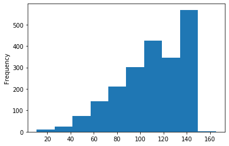

```python
tweets.tweet_limit.plot(kind = 'hist');
```

#### What’s the distribution of dog’s stage?

```python
#Getting the value of each category of dogs
doggos = tweets.dog_stages.value_counts()
doggos
```

```
pupper            216
doggo              74
puppo              24
floofer             9
doggo, pupper       9
doggo, puppo        1
doggo, floofer      1
Name: dog_stages, dtype: int64
```

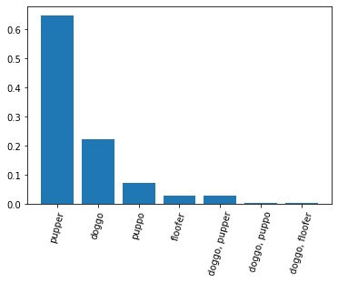

```python
#Getting the total sum of dogs
total = sum(tweets.dog_stages.value_counts())
#Creating a looping to extract dogs stage count and put in a list
dog_list = []
for d in doggos:
    stage = d
    dog_list.append(stage)

#Checking list
dog_list
#Now, a looping for getting the percentages
percent = []
for n in dog_list:
    divide = n / total
    percent.append(divide)
percent
#Finally, plotting the dog stage with percentages.
height = percent
location = [1,2,3,4,5,6,7]
labels = ('pupper','doggo','puppo','floofer','doggo, pupper','doggo, puppo','doggo, floofer')
plt.bar(location, height,tick_label = labels)
plt.xticks(rotation = '75');
```

#### What’s the distribuition of dogs rate?

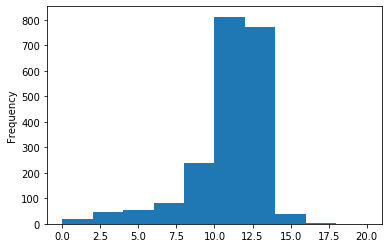

```python
tweets.numerator.plot(kind = "hist");
```

```python
tweets.shape
```

```
(2105, 24)
```

```python
tweets.numerator.describe()
```

```
count    2065.00000
mean       10.48245
std         2.48056
min         0.00000
25%        10.00000
50%        11.00000
75%        12.00000
max        20.00000
Name: numerator, dtype: float64
```